# Multiple Linear Regression

### G. Let’s take the quadratic model you have done so far. Can you check if the residuals follow a normal distribution?

**Answer:**

Let’s try the QQ-plot first. The graph by an eye test seems to indicate a normal distribution since many of the points are almost on the line. The line is slightly deviating from a $45^{\circ}$ angle, but still not much by eye test.

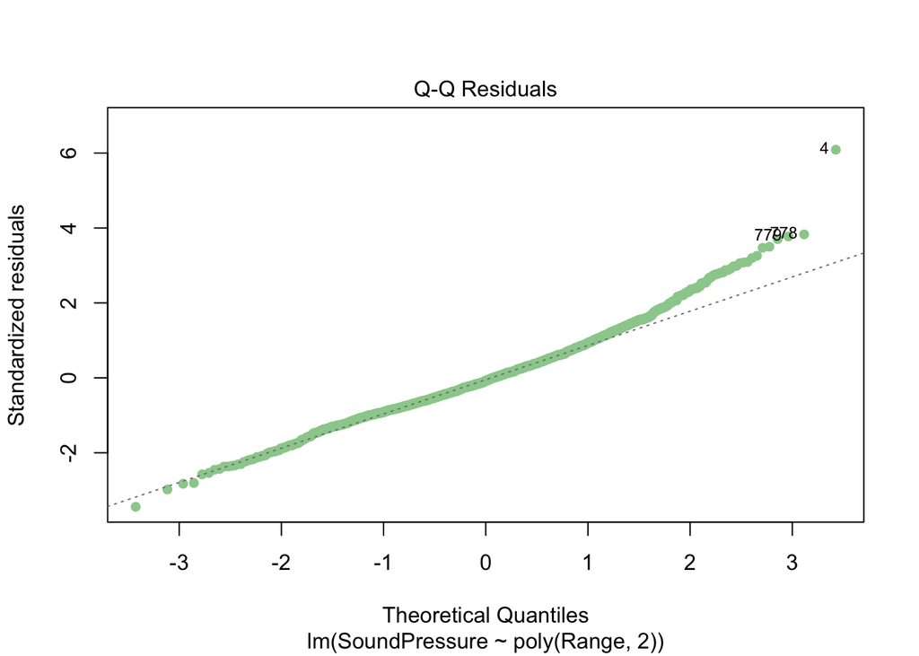

```r
plot(mod_polynomial, which = 2, pch=16, col="darkseagreen3")
```

Now, just to make sure, let’s do the Shapiro-Wilk test.

```r
shapiro.test(residuals(mod_polynomial))
```

```
##
##  Shapiro-Wilk normality test
##
## data:  residuals(mod_polynomial)
## W = 0.9813, p-value = 9.243e-14
```

This time, from the $p$ values, we can surely conclude that our initial intuition was wrong. Shapiro-Wilk test starts with the null hypothesis of normality, which we reject here following the small $p$ value.

### H. For the above, please plot the fitted vs residual plot. What comments can you make from this plot?

**Answer:**

Let’s follow the easier version of residual-against-fitted plot and not the one usually given by ChatGPT.

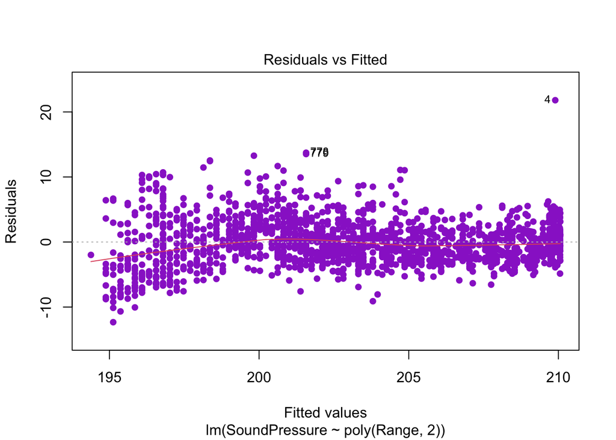

```r
plot(mod_polynomial, which = 1, pch = 16,
     col="darkorchid3")
```

From this plot, my first comment would be that there is an outlier in the data. Secondly, the ideal residual plot should not tell any story about the data. This time though, on the left side, below fitted value = 200, there is a slight visible pattern of curve. So, this plot suggests you that there is still some room for improvement in our modeling.

### I. Let’s take the linear regression model. Can you check if the residuals follow a normal distribution?

**Answer:**

Let’s do both the QQ-plot and the normality test.

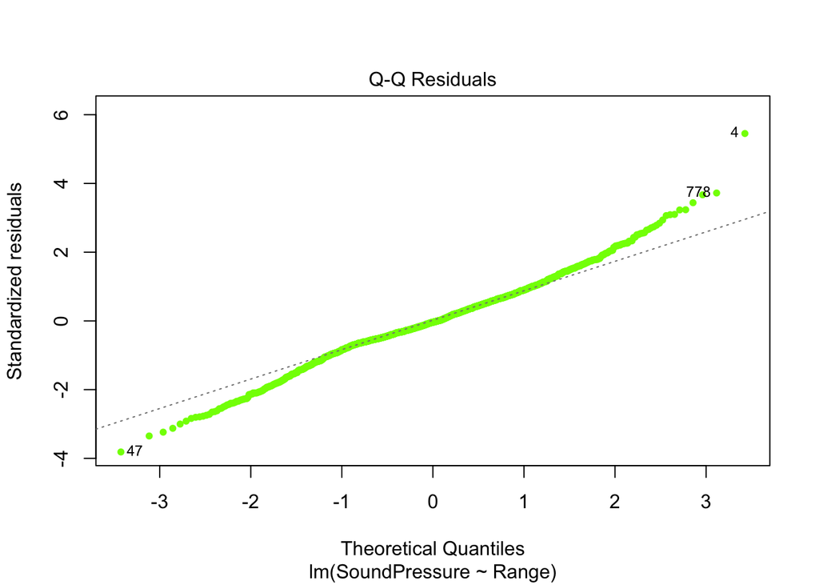

```r
plot(mod_linear, which = 2, pch = 20, col = "chartreuse")
```

```r
shapiro.test(  residuals(mod_linear))
```

```
##
##  Shapiro-Wilk normality test
##
## data:  residuals(mod_linear)
## W = 0.98801, p-value = 2.224e-10
```

The QQ-plot shows a big deviation from the line. Also, the Shapiro-Wilk test $p$ value clearly suggests a violation of normality.

### H. Again, take the linear regression model and draw the residual-vs-fitted plot. What comments can you make from this plot?

**Answer:**

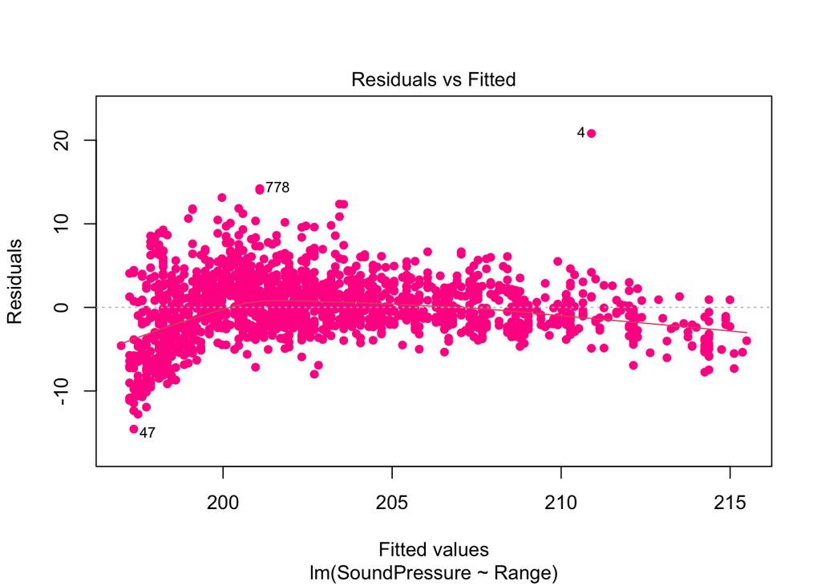

```r
plot(mod_linear, which = 1, pch = 16,
     col="deeppink")
```

# Question 3: Multicollinearity

[^1]

### Use the data on 20 individuals with high blood pressure from [here](https://online.stat.psu.edu/stat462/sites/onlinecourses.science.psu.edu.stat462/files/data/bloodpress/index.txt). The variables are:

| Description | Column Name |
| --- | --- |
| Blood pressure ( in mm Hg) | BP |
| Age (in years) | Age |
| Weight (in kg) | Weight |
| Body surface area (in sq m) | BSA |
| Duration of hypertension (in years) | Dur |
| Basal pulse (in beats per minute) | Pulse |
| Stress index | Stress |

### My following code downloads the data in a dataframe called $\texttt{bp_data}$, cleans it, and shows a snapshot of the data:

```r
bp_data = read.table(url("https://online.stat.psu.edu/stat462/sites/onlinecourses.science.psu.edu.stat462/files/data/bloodpress/index.txt"), header =TRUE)
bp_data[,1] = NULL
head(bp_data)
```

```
##    BP Age Weight  BSA Dur Pulse Stress
## 1 105  47   85.4 1.75 5.1    63     33
## 2 115  49   94.2 2.10 3.8    70     14
## 3 116  49   95.3 1.98 8.2    72     10
## 4 117  50   94.7 2.01 5.8    73     99
## 5 112  51   89.4 1.89 7.0    72     95
## 6 121  48   99.5 2.25 9.3    71     10
```

### A. We want to build a linear regression model with blood pressure as response and age, weight, body surface area, duration, pulse rate and/or stress level as predictors. Build the regression model.

**Answer:**

```r
bp_model = lm( BP ~ Age+ Weight+ BSA+ Dur+ Pulse+ Stress, data = bp_data )
summary(bp_model)
```

```
##
## Call:
## lm(formula = BP ~ Age + Weight + BSA + Dur + Pulse + Stress,
##     data = bp_data)
##
## Residuals:
##      Min       1Q   Median       3Q      Max
## -0.93213 -0.11314  0.03064  0.21834  0.48454
##
## Coefficients:
##               Estimate Std. Error t value Pr(>|t|)
## (Intercept) -12.870476   2.556650  -5.034 0.000229 ***
## Age           0.703259   0.049606  14.177 2.76e-09 ***
## Weight        0.969920   0.063108  15.369 1.02e-09 ***
## BSA           3.776491   1.580151   2.390 0.032694 *
## Dur           0.068383   0.048441   1.412 0.181534
## Pulse        -0.084485   0.051609  -1.637 0.125594
## Stress        0.005572   0.003412   1.633 0.126491
## ---
## Signif. codes:  0 '***' 0.001 '**' 0.01 '*' 0.05 '.' 0.1 ' ' 1
##
## Residual standard error: 0.4072 on 13 degrees of freedom
## Multiple R-squared:  0.9962, Adjusted R-squared:  0.9944
## F-statistic: 560.6 on 6 and 13 DF,  p-value: 6.395e-15
```

I did not ask this, but from the summary table, you can easily see that variables $\texttt{Dur, Pulse, Stress}$ are not significant. So if you had to do backward selection, you would start with dropping the least significant variable, $\texttt{Dur}$.

### B. Check if multicollinearity is present in the data using correlation coefficients. Take a cutoff of $\pm 0.65$.

**Answer:** Note, we only need the correlation values only for the predictors in this part. No need to include the response, $\texttt{BP}$ here.

```r
cor( bp_data[ c("Age",    "Weight",
"BSA"
,"Dur"
,"Pulse"
,"Stress" ) ])
```

```
##              Age     Weight        BSA       Dur     Pulse     Stress
## Age    1.0000000 0.40734926 0.37845460 0.3437921 0.6187643 0.36822369
## Weight 0.4073493 1.00000000 0.87530481 0.2006496 0.6593399 0.03435475
## BSA    0.3784546 0.87530481 1.00000000 0.1305400 0.4648188 0.01844634
## Dur    0.3437921 0.20064959 0.13054001 1.0000000 0.4015144 0.31163982
## Pulse  0.6187643 0.65933987 0.46481881 0.4015144 1.0000000 0.50631008
## Stress 0.3682237 0.03435475 0.01844634 0.3116398 0.5063101 1.00000000
```

Since the question asks you to check for the value $\pm 0.65$ (more than $0.65$ or less than $-0.65$), see that only possible high values are between $\texttt{Weight, BSA}$ and $\texttt{Weight, Pulse}$. So, going by the cutoff of $\pm 0.65$, there is evidence of multicollinearity in the data.

### C. Calculate the VIF of the model. Do you think there is multicollinearity in the data using a cutoff of $5$?

**Answer :** For the variance inflation function (VIF), you need to call the $\texttt{vif}$ function from the $\texttt{car}$ package. Just pass the name of the model here:

```r
car::vif(bp_model)
```

```
##      Age   Weight      BSA      Dur    Pulse   Stress
## 1.762807 8.417035 5.328751 1.237309 4.413575 1.834845
```

Going by the cutoff value of $5$ as in the question, note that both $\texttt{Weight}$ and $\texttt{BSA}$ have high VIF values. The interpretation is that both $\texttt{Weight}$ and $\texttt{BSA}$ are highly correlated with some linear combination of the other predictor variables, excluding themselves.

# Question 4: Logistic Regression

[^2]

### The frog abnormality dataset describes some characteristics of the Alaskan wood frog. There are some variables (namely $\texttt{ABNORMAL, SKEL_AB, EYE_AB, SURF_AB}$) that describes if there are some abnormality in the frogs or not. We will use predictors $\texttt{SVL, TAIL_LENGTH, BLEEDING_INJ}$ to predict $\texttt{Abnormal}$.

### The original data file was taken from https://datadryad.org/stash/dataset/doi:10.5061/dryad.sq72d. You can also access this data [here](https://github.com/dawranadeep/24FA_git/blob/main/Practice_qns/img/FrogAbnormalities.csv). Following code downloads the in a dataframe called $\texttt{frog_data}$ and shows a snapshot:

```r
frog_data = read.csv(url("https://raw.githubusercontent.com/dawranadeep/24FA_git/refs/heads/main/Practice_qns/img/FrogAbnormalities.csv"))
frog_data = frog_data[ complete.cases(frog_data$TAIL_LENGTH), ]
head(frog_data)
```

```
##          COLLECTION_ID FROG_ID GOSNER_STAGE SVL TAIL_LENGTH
## 1  KNA1021-RASY-080712      15           45  17           2
## 2  KNA1024-RASY-080812      13           44  22          20
## 3  KNA1069-RASY-080612      24           45  18           1
## 4  KNA1090-RASY-080612       5           45  17           3
## 5 KNA11119-RASY-081612      26           44  20          17
## 6  KNA1024-RASY-080812      47           44  21          33
##                                                                                                                                            FROG_COMMENTS
## 1
## 2
## 3
## 4
## 5
## 6 ~ 3mm of right thigh is comparable to left, remainder of thigh/calf are underdeveloped and foot is not fully developed, digits are not differentiated.
##   ABNORMAL BLEEDING_INJ SKEL_AB EYE_AB SURF_AB Perkensus      SITE      DATE
## 1        0            0       0      0       0         0   KNA1021  8/7/2012
## 2        0            0       0      0       0         0   KNA1024  8/8/2012
## 3        0            0       0      0       0         0   DNR1069  8/6/2012
## 4        0            0       0      0       0         0   KEN1090  8/6/2012
## 5        0            0       0      0       0         0 KNA111-19 8/16/2012
## 6        1            0       1      0       0         0   KNA1024  8/8/2012
##   YEAR
## 1 2012
## 2 2012
## 3 2012
## 4 2012
## 5 2012
## 6 2012
```

### 1. Build the logistic regression model here. Show the model summary.

**Answer:**

This is the model I am tying to build:

$$\begin{align*}
p_i &= \mathbb{P}[\text{$i$-th frog is abnormal], or
}\mathbb{P}[\text{ABNORMAL}_i = 1 ]\\
\log \frac{p_i}{1 - p_i} &= \beta_0 + \beta_1 * \text{SVL} + \beta_2
* \text{TAIL_LENGTH} + \beta_3 * \text{BLEEDING_INJ}
\end{align*}$$

```r
frog_model = glm(  ABNORMAL ~ SVL + TAIL_LENGTH + BLEEDING_INJ, data = frog_data, family = "binomial")
summary(frog_model)
```

```
##
## Call:
## glm(formula = ABNORMAL ~ SVL + TAIL_LENGTH + BLEEDING_INJ, family = "binomial",
##     data = frog_data)
##
## Coefficients:
##               Estimate Std. Error z value Pr(>|z|)
## (Intercept)  -1.013276   0.322431  -3.143 0.001674 **
## SVL          -0.063288   0.017143  -3.692 0.000223 ***
## TAIL_LENGTH   0.004817   0.002742   1.757 0.078932 .
## BLEEDING_INJ  3.718124   0.123142  30.194  < 2e-16 ***
## ---
## Signif. codes:  0 '***' 0.001 '**' 0.01 '*' 0.05 '.' 0.1 ' ' 1
##
## (Dispersion parameter for binomial family taken to be 1)
##
##     Null deviance: 6695.5  on 7703  degrees of freedom
## Residual deviance: 5346.5  on 7700  degrees of freedom
## AIC: 5354.5
##
## Number of Fisher Scoring iterations: 4
```

### 2. From the summary output, can you simplify the model?

**Answer:**

Look at the summary output of the above model. The predictor $\texttt{TAIL_LENGTH}$ is not significant at level $\alpha = 0.05$. So, we can drop it and simplify the model as the following.

```r
frog_model2 = glm(  ABNORMAL ~ SVL + BLEEDING_INJ, data = frog_data, family = "binomial")
summary(frog_model2)
```

```
##
## Call:
## glm(formula = ABNORMAL ~ SVL + BLEEDING_INJ, family = "binomial",
##     data = frog_data)
##
## Coefficients:
##              Estimate Std. Error z value Pr(>|z|)
## (Intercept)  -0.97302    0.32055  -3.035 0.002402 **
## SVL          -0.06107    0.01703  -3.587 0.000335 ***
## BLEEDING_INJ  3.73886    0.12271  30.470  < 2e-16 ***
## ---
## Signif. codes:  0 '***' 0.001 '**' 0.01 '*' 0.05 '.' 0.1 ' ' 1
##
## (Dispersion parameter for binomial family taken to be 1)
##
##     Null deviance: 6695.5  on 7703  degrees of freedom
## Residual deviance: 5349.6  on 7701  degrees of freedom
## AIC: 5355.6
##
## Number of Fisher Scoring iterations: 4
```

Since all the predictors are significant this time, this is where we can stop.

If you are interested in investigating the same using the inbuilt step function $\texttt{step}$, you will find a different answer.

```r
backward_frog_model = step(frog_model, direction = "backward")
```

```
## Start:  AIC=5354.53
## ABNORMAL ~ SVL + TAIL_LENGTH + BLEEDING_INJ
##
##                Df Deviance    AIC
## <none>              5346.5 5354.5
## - TAIL_LENGTH   1   5349.6 5355.6
## - SVL           1   5360.2 5366.2
## - BLEEDING_INJ  1   6658.4 6664.4
```

Notice in the output above that the AIC value is lowest for the initial model (i.e., no variables dropped from the model in part A). Whenever the algorithm tries to remove a variable, the AIC increases, making those models less preferable than the original model in part A. Therefore, after completing the backward elimination process using AIC, you’ll end up with the model from part A.

```r
summary(backward_frog_model)
```

```
##
## Call:
## glm(formula = ABNORMAL ~ SVL + TAIL_LENGTH + BLEEDING_INJ, family = "binomial",
##     data = frog_data)
##
## Coefficients:
##               Estimate Std. Error z value Pr(>|z|)
## (Intercept)  -1.013276   0.322431  -3.143 0.001674 **
## SVL          -0.063288   0.017143  -3.692 0.000223 ***
## TAIL_LENGTH   0.004817   0.002742   1.757 0.078932 .
## BLEEDING_INJ  3.718124   0.123142  30.194  < 2e-16 ***
## ---
## Signif. codes:  0 '***' 0.001 '**' 0.01 '*' 0.05 '.' 0.1 ' ' 1
##
## (Dispersion parameter for binomial family taken to be 1)
##
##     Null deviance: 6695.5  on 7703  degrees of freedom
## Residual deviance: 5346.5  on 7700  degrees of freedom
## AIC: 5354.5
##
## Number of Fisher Scoring iterations: 4
```

This highlights the importance of understanding various criteria for a single problem and examining how they all behave.

### 3. Check for multicollinearity in the data using both correlation and the VIF. Do you think there is multicollinearity?

**Answer:** Just print the correlation coefficients and the vif values. You will see that there is no problem of multicollinearity in this particular model.

```r
cor( frog_data[ c("SVL", "TAIL_LENGTH", "BLEEDING_INJ")])
```

```
##                     SVL TAIL_LENGTH BLEEDING_INJ
## SVL          1.00000000  0.04950068   0.01071263
## TAIL_LENGTH  0.04950068  1.00000000   0.09025493
## BLEEDING_INJ 0.01071263  0.09025493   1.00000000
```

```r
car::vif( frog_model )
```

```
##          SVL  TAIL_LENGTH BLEEDING_INJ
##     1.010575     1.014214     1.011217
```

[^1]: Courtesy: https://online.stat.psu.edu/stat462/node/177/
[^2]: Courtesy: https://datadryad.org/stash/dataset/doi:10.5061/dryad.sq72d